# 用DESeq2包来对RNA-seq数据进行差异分析

jmzeng

2016年4月11日

> 差异分析的套路都是差不多的，大部分设计思想都是继承limma这个包，DESeq2也不例外。

> DESeq2是DESeq包的更新版本，看样子应该不会有DESeq3了，哈哈，它的设计思想就是针对count类型的数据。

> 可以是任意features的count数据，比如对各个基因的count，或者外显子，或者CHIP-seq的一些feature，都可以用来做差异分析。

使用这个包也是需要三个数据：

- 表达矩阵
- 分组矩阵
- 差异比较矩阵

总结起来三个步骤，我下面会一一讲解

- 重点就是构造一个dds的对象，
- 然后直接用DESeq函数进行normalization处理即可，
- 处理之后用results函数来提取差异比较结果

## 读取自己的数据

一般我们会自己读取表达矩阵和分组信息，下面是一个例子：

```r
options(warn=-1)
suppressMessages(library(DESeq2))
suppressMessages(library(limma))
suppressMessages(library(pasilla))
data(pasillaGenes)
exprSet=counts(pasillaGenes)
head(exprSet)  ##表达矩阵如下
```

```
##             treated1fb treated2fb treated3fb untreated1fb untreated2fb
## FBgn0000003          0          0          1            0            0
## FBgn0000008         78         46         43           47           89
## FBgn0000014          2          0          0            0            0
## FBgn0000015          1          0          1            0            1
## FBgn0000017       3187       1672       1859         2445         4615
## FBgn0000018        369        150        176          288          383
##             untreated3fb untreated4fb
## FBgn0000003            0            0
## FBgn0000008           53           27
## FBgn0000014            1            0
## FBgn0000015            1            2
## FBgn0000017         2063         1711
## FBgn0000018          135          174
```

```r
(group_list=pasillaGenes$condition)
```

```
## [1] treated   treated   treated   untreated untreated untreated untreated
## Levels: treated untreated
```

```r
##这是分组信息，7个样本，3个处理的，4个未处理的对照！
```

## 第一步：构建dds对象

那么根据这两个数据就可以构造dds的对象了

```r
colData <- data.frame(row.names=colnames(exprSet),
                       group_list=group_list
                       )
## 这是一个复杂的方法构造这个对象！
dds <- DESeqDataSetFromMatrix(countData = exprSet,
                              colData = colData,
                              design = ~ group_list)

## design 其实也是一个对象，还可以通过design(dds)来继续修改分组信息，但是一般没有必要。
dds
```

```
## class: DESeqDataSet
## dim: 14470 7
## exptData(0):
## assays(1): counts
## rownames(14470): FBgn0000003 FBgn0000008 ... FBgn0261574
##   FBgn0261575
## rowData metadata column names(0):
## colnames(7): treated1fb treated2fb ... untreated3fb untreated4fb
## colData names(1): group_list
```

可以看到我们构造的dds对象有7个样本，共14470features

从基因名可以看出，是果蝇的测序数据

我们也可以直接从expressionSet这个对象构建dds对象！

```r
library(airway)
data(airway)
suppressMessages(library(DESeq2))
dds  <- DESeqDataSet(airway, design = ~ cell+ dex)
design(dds) <- ~ dex
## 构造好的对象还可以更改分组信息
```

## 第二步：做normalization

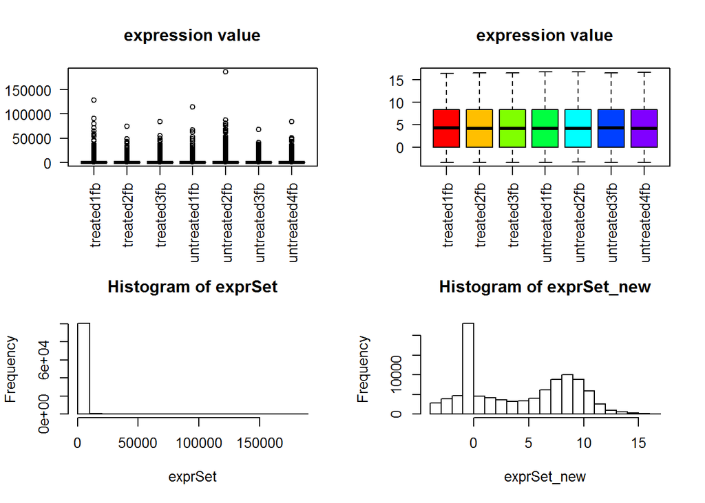

```r
suppressMessages(dds2 <- DESeq(dds))
##直接用DESeq函数即可
## 下面的代码如果你不感兴趣不需要运行，免得误导你
## 就是看看normalization前面的数据分布差异
rld <- rlogTransformation(dds2)  ## 得到经过DESeq2软件normlization的表达矩阵！
exprSet_new=assay(rld)
par(cex = 0.7)
n.sample=ncol(exprSet)
if(n.sample>40) par(cex = 0.5)
cols <- rainbow(n.sample*1.2)
par(mfrow=c(2,2))
boxplot(exprSet, col = cols,main="expression value",las=2)
boxplot(exprSet_new, col = cols,main="expression value",las=2)
hist(exprSet)
hist(exprSet_new)
```

## 第三步：提取差异分析结果

```r
resultsNames(dds2)
```

```
## [1] "Intercept"           "group_listtreated"   "group_listuntreated"
```

```r
## 其实如果只分成了两组，并没有必要指定这个比较矩阵！
res <-  results(dds2, contrast=c("group_list","treated","untreated"))

## 提取你想要的差异分析结果，我们这里是trt组对untrt组进行比较
resOrdered <- res[order(res$padj),]
resOrdered=as.data.frame(resOrdered)
head(resOrdered)
```

```
##              baseMean log2FoldChange     lfcSE      stat        pvalue
## FBgn0039155  453.2753      -4.281830 0.1919977 -22.30146 3.576174e-110
## FBgn0029167 2165.0445      -2.182745 0.1080670 -20.19807  1.017931e-90
## FBgn0035085  366.8279      -2.436860 0.1505280 -16.18875  6.054219e-59
## FBgn0029896  257.9027      -2.511257 0.1823764 -13.76964  3.881667e-43
## FBgn0034736  118.4074      -3.166392 0.2375506 -13.32933  1.562878e-40
## FBgn0040091  610.6035      -1.526400 0.1278555 -11.93848  7.457520e-33
##                      padj
## FBgn0039155 2.764025e-106
## FBgn0029167  3.933795e-87
## FBgn0035085  1.559769e-55
## FBgn0029896  7.500351e-40
## FBgn0034736  2.415897e-37
## FBgn0040091  9.606528e-30
```

差异分析结果很容易看懂啦！